# Final Project: Food Inspection Failures in Chicago

#### Additional Risk Factors

*Distance to The Loop* - Another factor considered by the model is distance from Chicago’s downtown area called “The Loop.” In the Exploratory Analysis section, it was noted that The Loop has a high number of failed inspections. This factor looks to operationalize that observation by creating a risk factor. Distance to The Loop is plotted below to the left.

*Is Significant Hot Spot* - The binary variable mapping whether a given cell is a hot spot or not is also included.

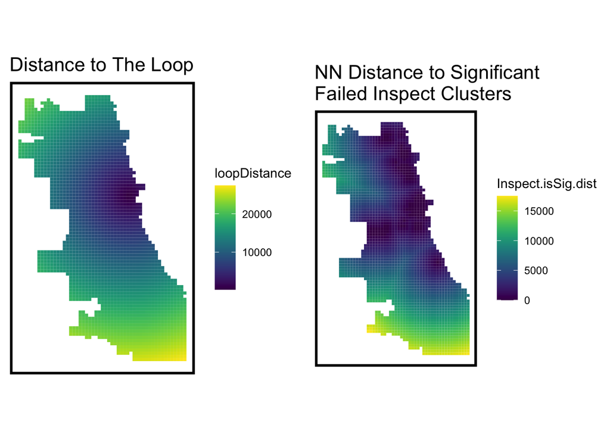

```r
#Distance to Loop to be used later
loopPoint <-
  filter(neighborhoods, name == "Loop") %>%
  st_centroid()
  vars_net$loopDistance =
  st_distance(st_centroid(vars_net), loopPoint) %>%
  as.numeric()

## important to drop the geometry from joining features
final_net <-
  left_join(inspect_net, st_drop_geometry(vars_net), by="uniqueID")

## generates warnings from PROJ issues
## {spdep} to make polygon to neighborhoods...
final_net.nb <- poly2nb(as_Spatial(final_net), queen=TRUE)
## ... and neighborhoods to list of weigths
final_net.weights <- nb2listw(final_net.nb, style="W", zero.policy=TRUE)
# print(final_net.weights, zero.policy=TRUE)

## see ?localmoran
local_morans <- localmoran(final_net$countInspect, final_net.weights, zero.policy=TRUE) %>%
  as.data.frame()

# join local Moran's I results to fishnet
final_net.localMorans <-
  cbind(local_morans, as.data.frame(final_net)) %>%
  st_sf() %>%
  dplyr::select(countInspect = countInspect,
                Local_Morans_I = Ii,
                P_Value = `Pr(z != E(Ii))`) %>%
  mutate(Significant_Hotspots = ifelse(P_Value <= 0.001, 1, 0)) %>%
  gather(Variable, Value, -geometry)


# generates warning from NN
final_net <- final_net %>%
  mutate(Inspect.isSig =
           ifelse(local_morans[,5] <= 0.001, 1, 0)) %>%
  mutate(Inspect.isSig.dist =
           nn_function(st_c(st_coid(final_net)),
                       st_c(st_coid(filter(final_net,
                                           Inspect.isSig == 1))),
                       k = 1))
grid.arrange(ncol=2,
  ggplot() +
    geom_sf(data = vars_net, aes(fill=loopDistance), colour=NA) +
    scale_fill_viridis(name="loopDistance") +
    labs(title="Distance to The Loop") +
    mapTheme(),
  ggplot() +
    geom_sf(data = final_net, aes(fill=Inspect.isSig.dist), colour=NA) +
    scale_fill_viridis(name="Inspect.isSig.dist") +
    labs(title="NN Distance to Significant \nFailed Inspect Clusters") +
    mapTheme()
)
```

### Risk Factor Correlations

As a part of our modeling approach, we analyzed individual linear relationships between 2018 risk factors and 2018 inspection failures across Chicago’s fishnet cells. The results of this analysis are displayed in the plots below, with the r-value of each relationship (1.0 corresponding to the strongest positive correlation, 0.0 corresponding to no correlation, and -1.0 corresponding to the strongest negative correlation) displayed in the upper-left corner of each plot.

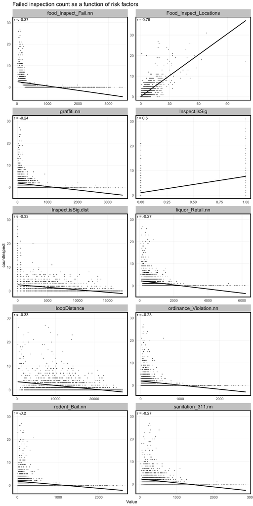

```r
correlation.long <-
  st_drop_geometry(final_net) %>%
  dplyr::select(-uniqueID, -cvID, -Sanitation_311, -Ordinance_Violations, -Graffiti, -Liquor_Retail, -Rodent_Bait, -Food_Inspect_Fail) %>%
  gather(Variable, Value, -countInspect)

# colnames(final_net)

# , foodInspectLocations, -Inspect.isSig,-name,

correlation.cor <-
  correlation.long %>%
  group_by(Variable) %>%
  summarize(correlation = cor(Value, countInspect, use = "complete.obs"))

ggplot(correlation.long, aes(Value, countInspect)) +
  geom_point(size = 0.1) +
  geom_text(data = correlation.cor,
  aes(label = paste("r =", round(correlation, 2))),
  x=-Inf, y=Inf, vjust = 1.5, hjust = -.1) +
geom_smooth(method = "lm", se = FALSE, colour = "black") +
facet_wrap(~Variable, ncol = 2, scales = "free") +
labs(title = "Failed inspection count as a function of risk factors") +
plotTheme()
```

```r
# Join neighborhood data by attaching centroids of fishnets to a polygon of neighborhoods.

# This will be useful later
final_net <-
  st_centroid(final_net) %>%
    st_join(dplyr::select(neighborhoods, name), by = "uniqueID") %>%
      st_drop_geometry() %>%
      left_join(dplyr::select(final_net, geometry, uniqueID)) %>%
      st_sf() %>%
  na.omit()
```

The basic results of these analyses confirm our expectations. *Inspection Locations* has the most significant linear relationship with inspection failure locations. *Is Significant Hot Spot* also stood out, the binary version markedly more correlated than *Significant Hot Spot (3NN)*. *Distance to The Loop* had a negative correlation with inspection failures, as expected. *Inspection Failure Locations (3NN)*, in addition to the five other 3NN risk factors from the Chicago Data Portal, had slight negative correlations with inspection failures. At a glance, these relationships look more logarithmic than linear. Surprisingly, log versions of these variables did not provide for a more robust model. Despite experimentation with logarithmic feature engineering, *Inspection Failure Locations (3NN)* and the other 3NN Chicago Data Portal risk factors are included in their original forms in the final version of the model.

### Local Moran’s I results

The grid map below shows the following four elements:

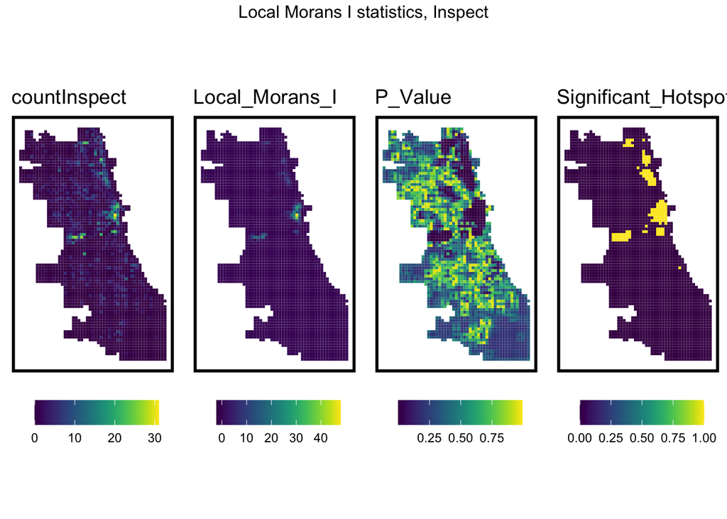

```r
## This is just for plotting
vars <- unique(final_net.localMorans$Variable)
varList2 <- list()

for(i in vars){
  varList2[[i]] <-
    ggplot() +
      geom_sf(data = filter(final_net.localMorans, Variable == i),
              aes(fill = Value), colour=NA) +
      scale_fill_viridis(name="") +
      labs(title=i) +
      mapTheme(title_size = 14) + theme(legend.position="bottom")}

do.call(grid.arrange,c(varList2, ncol = 4, top = "Local Morans I statistics, Inspect"))
```

These four elements clearly indicate spatial patterns in the failed inspections data. This supports the use of a fishnet-based model of prediction. It also supports the decision to take a spatial approach in selecting risk factors - if spatial relationships are key to understanding failed inspections, they are likely key to predicting failed inspections too.

# 5. Modeling with Cross Validation

K-fold was not the only kind of validation considered as a part of this project. ‘Leave-one-group-out’ cross-validation (LOGO-CV) was also considered. LOGO CV considers groups of data (in this case, Chicago’s neighborhoods), and trains the whole model on every possible combination of groups such that one group is always missing from the analysis. This may help when one group has a unique relationship to the dependent variable.  
Two versions of each cross-validation method were undertaken, each using a different set of independent variables. The first, more limited set includes only the food inspection failures, food inspection locations, and the five factors from Chicago’s open data website. The second set of independent variables for each cross-validation method includes all of the previously listed risk factors. In total, four variations of the model are generated.

1. *Random k-fold CV: Limited Set*
2. *Random k-fold CV: All Risk Factors*
3. *Spatial LOGO-CV: Limited Set*
4. *Spatial LOGO-CV: All Risk Factors*

```r
# necessary workaround for hardcoded "countBurglaries"
# redefine function
remove(crossValidate)
crossValidate <- function(dataset, id, dependentVariable, indVariables) {

 allPredictions <- data.frame()
 cvID_list <- unique(dataset[[id]])

 for (i in cvID_list) {

  thisFold <- i
  #cat("This hold out fold is", thisFold, "\n")

  fold.train <- filter(dataset, dataset[[id]] != thisFold) %>% as.data.frame() %>%
   dplyr::select(id, geometry, indVariables, dependentVariable)
  fold.test <- filter(dataset, dataset[[id]] == thisFold) %>% as.data.frame() %>%
   dplyr::select(id, geometry, indVariables, dependentVariable)

  regression <-
    glm(paste0(dependentVariable,"~."), family = "poisson",
     data = fold.train %>%
      dplyr::select(-geometry, -id))
  thisPrediction <-
   mutate(fold.test, Prediction = predict(regression, fold.test, type = "response"))

  allPredictions <-
   rbind(allPredictions, thisPrediction)

 }
 return(st_sf(allPredictions))
}

# View(crossValidate)

## define independent variables
reg.ss.vars <- c("rodent_Bait.nn", "sanitation_311.nn","ordinance_Violation.nn", "graffiti.nn", "liquor_Retail.nn", "food_Inspect_Fail.nn", "Food_Inspect_Locations", "Inspect.isSig", "Inspect.isSig.dist", "loopDistance")

## define independent variables with spatial features
reg.vars <-
c("rodent_Bait.nn", "sanitation_311.nn","ordinance_Violation.nn", "graffiti.nn", "liquor_Retail.nn", "food_Inspect_Fail.nn", "Food_Inspect_Locations")

## RUN REGRESSIONS
reg.ss.spatialCV <- crossValidate(
  dataset = dplyr::rename(final_net, countFailures = countInspect),
  id = "name",
  dependentVariable = "countFailures",
  indVariables = reg.ss.vars) %>%
    dplyr::select(cvID = name, countFailures, Prediction, geometry)


reg.cv <- crossValidate(
  dataset = dplyr::rename(final_net, countFailures = countInspect),
  id = "cvID",
  dependentVariable = "countFailures",
  indVariables = reg.vars) %>%
    dplyr::select(cvID = cvID, countFailures, Prediction, geometry)


reg.ss.cv <- crossValidate(
  dataset = dplyr::rename(final_net, countFailures = countInspect),
  id = "cvID",
  dependentVariable = "countFailures",
  indVariables = reg.ss.vars) %>%
  dplyr::select(cvID = cvID, countFailures, Prediction, geometry)


reg.spatialCV <- crossValidate(
  dataset = dplyr::rename(final_net, countFailures = countInspect),
  id = "name",
  dependentVariable = "countFailures",
  indVariables = reg.vars) %>%
  dplyr::select(cvID = name, countFailures, Prediction, geometry)

reg.summary <-rbind(
  mutate(reg.cv,
  Error = Prediction - countFailures,
  Regression = "Random k-fold CV: Limited Set"),

  mutate(reg.ss.cv,
  Error = Prediction - countFailures,
  Regression = "Random k-fold CV: All Risk Factors"),

  mutate(reg.spatialCV,
  Error = Prediction - countFailures,
  Regression = "Spatial LOGO-CV: Limited Set"),

  mutate(reg.ss.spatialCV,
  Error = Prediction - countFailures,
  Regression = "Spatial LOGO-CV: All Risk Factors")) %>%
st_sf()

# calculate errors by NEIGHBORHOOD
error_by_reg_and_fold <-
  reg.summary %>%
  group_by(Regression, cvID) %>%
    summarize(Mean_Error = mean(Prediction - countFailures, na.rm = T),
              MAE = mean(abs(Mean_Error), na.rm = T),
              SD_MAE = mean(abs(Mean_Error), na.rm = T)) %>%
  ungroup()

error_by_reg_and_fold %>%
  arrange(desc(MAE))

# error_by_reg_and_fold %>%
#   arrange(MAE)
```

### Measuring Model Accuracy and Generalizability

For our model, we wanted to adopt the version of these four models which, using 2018 data, could make the most accurate and generalizable predictions of 2018 failure counts. A model’s ability to predict for its own year in an *accurate* and *generalizable* way points to effectiveness in consistently providing well-grounded predictions for the following year.

A model’s accuracy can be assessed with Mean Absolute Error (MAE). The MAE of a model measures the average difference between true value and predicted value across each data point (for the purposes of these model variations, each fishnet cell). A model’s MAE is an indicator of its accuracy. Generalizability can also be analyzed by considering MAE across different portions of a dataset. Even if overall MAE is low, there may be portions of the dataset where predictions perform disproportionately poorly.

To compare model generalizability, The distributions of MAE across Chicago neighborhood are displayed for each of the four model variations. Below, mean neighborhood MAE and the size of a standard deviation are also displayed.

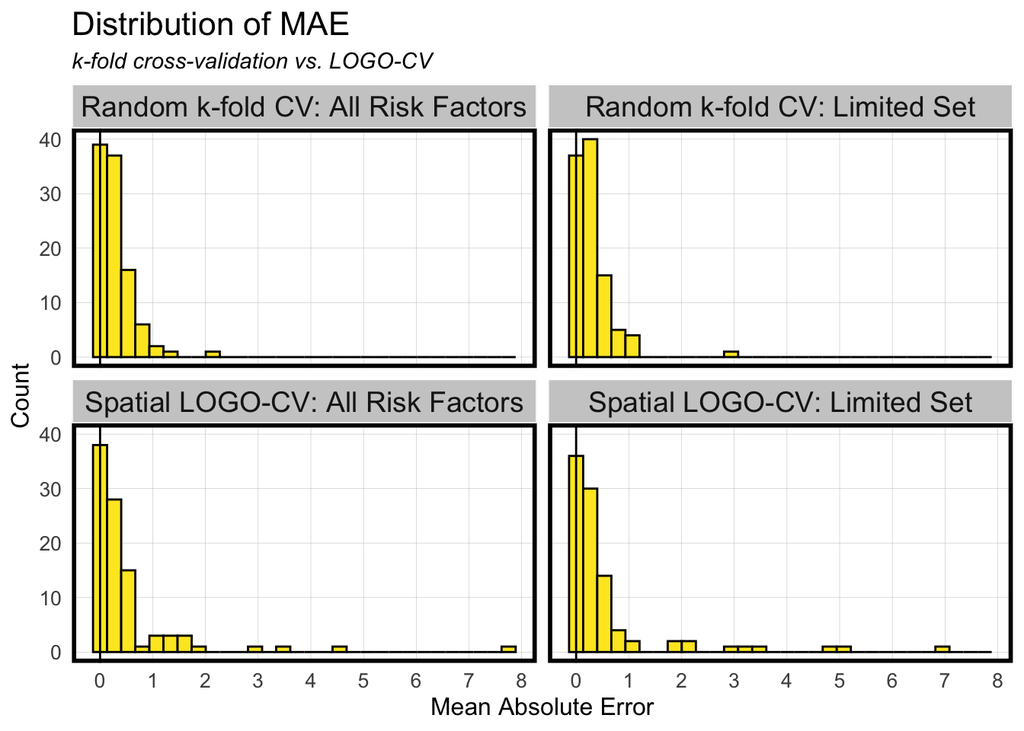

```r
## plot histogram of OOF (out of fold) errors
error_by_reg_and_fold %>%
  ggplot(aes(MAE)) +
  geom_histogram(bins = 30, colour="black", fill="#FDE725FF") +
  facet_wrap(~Regression) +
  geom_vline(xintercept = 0) + scale_x_continuous(
  breaks = seq(0, 8, by = 1)) +
  labs(title="Distribution of MAE",
  subtitle = "k-fold cross-validation vs. LOGO-CV",
  x="Mean Absolute Error", y="Count") +
plotTheme()
```

```r
## Errors by Model
st_drop_geometry(error_by_reg_and_fold) %>%
  group_by(Regression) %>%
  summarize(Mean_MAE = round(mean(MAE), 2),
  SD_MAE = round(sd(MAE), 2)) %>%
  kable() %>%
  kable_styling("striped", full_width = F) %>%
  row_spec(2, color = "black", background = "#FDE725FF") %>%
  row_spec(4, color = "black", background = "#FDE725FF")
```

| Regression | Mean_MAE | SD_MAE |
| --- | --- | --- |
| Random k-fold CV: All Risk Factors | 0.31 | 0.32 |
| Random k-fold CV: Limited Set | 0.32 | 0.37 |
| Spatial LOGO-CV: All Risk Factors | 0.52 | 1.04 |
| Spatial LOGO-CV: Limited Set | 0.59 | 1.13 |

# 6. Model Usefulness

The model and its capability to predict Chicago food inspection failures is useful to a variety of municipal agencies and officials. This is because it allows for a data-driven, cost-effective distribution of the city’s 36 food inspectors. Failed inspections require follow-up inspections, so by forecasting the distribution of failures, cities and their employees can make a better determination of how many total inspections will be necessary in a given year.

The plot below illustrates predictions generated for the year 2019. For each cell in the fishnet, a value is generated to forecast the number of failures that will be logged over the course of the year. The value is not a whole number - it is designed to give as much information as possible to its user rather to produce a discrete prediction for each cell. This gives the user a sharper and more specific understanding of the tool’s results.

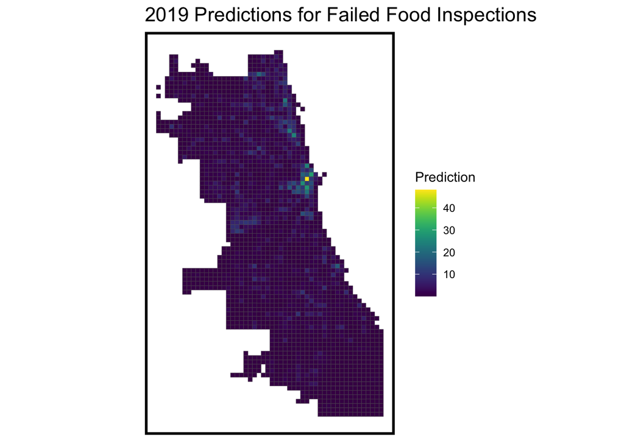

```r
ggplot() +
  geom_sf(data = reg.ss.cv, aes(fill = Prediction), size=0.1, show.legend = "point") +
  scale_fill_viridis(name="Prediction") +
  labs(title= "2019 Predictions for Failed Food Inspections") +
  mapTheme()
```

The model is also useful in that it can be easily understood and explained relatively easily. The best outcome is one where those in power know how and why the model works. Unlike some “black box” algorithms whose inner workings are a mystery even to some of the people putting them into action, policymakers and even the public can understand this straightforward model.

# 7. Meeting the Use Case: Additional Design Elements

Several additional elements of this application help this model meet its use case, including tiered scheduling, a weather-specific inspection trigger mechanism, and 311 call inspection trigger mechanism.

#### Tiered Scheduling

Once this model produces a set of predictions for a given year, its work is not yet done. Having used its modeling feature to create a set of predictions, the application assigns teams of inspectors to groups of fishnet cells with proportional numbers of predicted inspectors. These teams can get to know an area and the local health factors that are relevant to restaurants in their zone.

The scheduling element of this application prioritizes certain restaurants within each zone to receive earlier inspections based on their individual risk designation by the Chicago Health Department (the department already ranks restaurants as “high,” “medium,” and “low,” risk). These assessments are used as priority tiers such that restaurants with higher Health Department risk rankings are prioritized within an inspection team’s focus area.

#### Weather-specific Triggers

Weather has been shown to have measurable impacts on food inspection pass rates. Specifically, very hot weather produces higher rates of failures. Restaurants in Chicago should be expected to follow Department of Health guidelines regardless of the weather, including during periods of extremely hot weather. A three-day period of above average whether in Chicago during the summer triggers immediate inspections of high-risk restaurants if inspections are needed at any individual locations.

#### 3-1-1 Call trigger Mechanism

Our application also makes the most of Chicago’s 311 non-emergency City Services line with a mechanism to prioritize inspections in response to repeated calls. When excessive calls regarding a restaurant needing inspection are logged from different numbers (to prevent abuse of the mechanism) on multiple different days (to avoid over-penalization of specific events that result in multiple calls) over the course of a two-week period, an inspection is immediately triggered.

### Shortening the Feedback Loop

Our model, supplemented with the previously mentioned additional elements, is designed with the big-picture goal of “shortening the feedback loop” in mind. The feedback loop that exists in food inspection where restaurants follow or fail to follow health codes, are inspected, and take the result into account whether they choose to follow or fail to follow health codes.

When restaurants choose unsafe practices, it is critical that this feedback loop is shortened so that there is as little chance as possible that unsafe practices lead to an outbreak such as the 2016 E. Coli outbreak in Chicago’s Bridgeport neighborhood. This application works to shorten the food inspection feedback loop with solid foundation of failure prediction, enhanced by additional design elements that result in efficient inspections taking place where unsafe practices are more likely.

# 8. Improvement

There are several ways that the model - the foundation of the application - could be improved. First, predictions for a given year would likely be improved if they considered prospective inspection locations for that year. Ostensibly, the city has a database of locations it expects to inspect in a given year long before the year starts, and the use of this data could significantly improve the model. Additionally, more temporally-specific predictions could make scheduling inspectors more efficient. Predicting the failures expected for a quarter rather than a year would allow for better overall process. Finally, measures could be taken to ensure the model is not overly punitive of small and minority-owned businesses due to neighborhood-level factors out of the business owners’ control. A good model of inspections must consider spatial factors, and while implicit bias will always be present, it is the job of the data scientist to discern and minimize its impact on the predictions.